# Estimating biodiversity loss from habitat loss using rcoalescence

# Background

The goal of this vignette is to demonstrate the workflow for simulating a habitat loss scenario using rcoalescence and estimating biodiversity losses in different areas of the landscape. It is an extended version of the vignette found within the `rcoalescence` package itself, aimed at supporting Thompson *et al* (2020).

We are interested in simulating the effect of habitat loss for a taxon. In our scenario, there is currently an area of land consisting of a protected national park and mixed forest and farmland in the surrounding area. We estimate that the protected national park supports approximately 10 individuals of our taxon per kilometer of complete forest and 0 - 5 individuals per kilometer in the surrounding area, depending on the forest coverage.

We wish to model the scenario where a significant portion of the land is completed deforested, resulting in 0 individuals per kilometer in the given area.

For the purposes of this demo, maps were extracted and edited from Global Forest Watch (Greenpeace, University of Maryland, and World Resources Institute and Transparent World 2016). In our model, each pixel on the maps represents one square kilometer.

First we read the map files and count the number of individuals.

```r
source_file <- file.path("images", "ifl_2016_pre.tif")
source_file_post <- file.path("images", "ifl_2016_post.tif")
source_national_park <- file.path("images", "ifl_national_park.tif")
suppressWarnings({
  pre_data <- readTIFF(source_file)
})
suppressWarnings({
  post_data <- readTIFF(source_file_post)
})
suppressWarnings({
  national_park_data <- readTIFF(source_national_park)
})

total_individuals_prior <- sum(floor(pre_data * 10))
total_individuals_post <- sum(floor(post_data * 10))
total_individuals_national_park <- sum(floor(national_park_data * 10))
total_aspect_ratio <- nrow(pre_data)/ncol(pre_data)
```

## Requirements

This vignette requires approximately 4GB of hard drive storage (for simulation outputs) and a reasonably modern processor with >4GB of RAM.

## Key goals

The modelling aims to answer the following questions:

- How many species are expected to be lost from the habitat loss?
- What is the spatial distribution of biodiversity (measured by average number of species per kilometer) before and after the habitat loss?

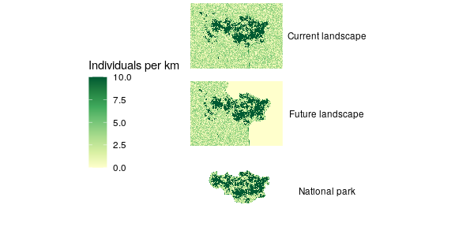

Landscape patterns for our model. Each pixel represents one squared kilometer. The national park is represented a within a subset of the landscape, mostly consisting of high quality habitat.

# Running the simulation

Running the simulation is split into three key steps. First, all the simulation parameters are set. Next, the simulation is run. Finally, the community is reconstructed and saved to an output database. At this point, biodiversity metrics can be calculated using the in-built functions or directly from the output database.

These variables define some important simulation parameters. It is often useful to keep these parameters in one place.

```r
# Sample every 5 generations over 110 generations
times_list <- seq(0, 110, 5)
min_speciation_rate <- 0.0001
sigma <- 1
# 100 generations between the map types
# Set to 99.9 so that the map changes by the just before the 100th generation
time_difference_between_maps <- 99.9
```

## Create the simulation objects

We create our new `SpatialTreeSimulation` object and set the simulation parameters. We then perform the simulation and apply speciation rates. We also extract the species locations, species richness and species abundances for the simulation. We repeat the above process ten times with different random number seeds.

```r
species_locations <- NULL
species_abundances <- NULL
species_richness <- NULL
pmt <- proc.time()
for (seed in seq(1, 10))
{
  print(paste("Running simulation number", seed))
  output_path <- file.path(output_dir, paste0("data_1_", seed, ".db"))
  sim <- SpatialTreeSimulation$new()
  if (file.exists(output_path)) {
    sim$setOutputDatabase(output_path)
  } else {
    sim$setSimulationParameters(
      task = 1,
      seed = seed,
      output_directory = output_dir,
      min_speciation_rate = min_speciation_rate,
      times_list = times_list,
      uses_logging = FALSE,
      fine_map_file = source_file_post,
      deme = 10,
      historical_fine_map = source_file,
      gen_since_historical = time_difference_between_maps,
      habitat_change_rate = 0.0,
      sigma = sigma,
      dispersal_method = "normal",
      landscape_type = "tiled_fine"
    )
    sim$runSimulation()
    sim$applySpeciationRates(
      speciation_rates = c(min_speciation_rate),
      times_list = times_list,
      use_spatial = TRUE
    )
    sim$output()
  }
  all_references <- sim$getCommunityReferences()$reference
  tmp_locations <- sim$getSpeciesLocations(all_references) %>%
    mutate(seed = seed)
  tmp_abundances <- sim$getSpeciesAbundances(all_references) %>%
    mutate(seed = seed)
  tmp_richnesses <- sim$getSpeciesRichness(all_references) %>%
    mutate(seed = seed)
  if (is.null(species_locations)) {
    species_locations <- tmp_locations
  } else {
    species_locations <- species_locations %>%
      bind_rows(tmp_locations)
  }
  if (is.null(species_abundances)) {
    species_abundances <- tmp_abundances
  } else {
    species_abundances <- species_abundances %>%
      bind_rows(tmp_abundances)
  }
  if (is.null(species_richness)) {
    species_richness <- tmp_richnesses
  } else {
    species_richness <- species_richness %>%
      bind_rows(tmp_richnesses)
  }
}
```

```
#> [1] "Running simulation number 1"
#> [1] "Running simulation number 2"
#> [1] "Running simulation number 3"
#> [1] "Running simulation number 4"
#> [1] "Running simulation number 5"
#> [1] "Running simulation number 6"
#> [1] "Running simulation number 7"
#> [1] "Running simulation number 8"
#> [1] "Running simulation number 9"
#> [1] "Running simulation number 10"
```

```r
proc.time() - pmt
```

```
#>    user  system elapsed
#>  30.755   1.308  33.572
```

```r
species_richness <- species_richness %>%
  full_join(sim$getCommunityReferences() %>%
    rename(community_reference = reference),
  by = "community_reference"
  )
```

```r
mean_richness_before <- species_richness %>%
  filter(time >= 100) %>%
  select(species_richness) %>%
  pull() %>%
  mean()
mean_richness_after <- species_richness %>%
  filter(time < 100) %>%
  select(species_richness) %>%
  pull() %>%
  mean()
mean_species_richness <- species_richness %>%
  select(community_reference, species_richness, speciation_rate, time, seed) %>%
  group_by(community_reference, time) %>%
  summarise(
    mean_species_richness = mean(species_richness),
    min_species_richness = min(species_richness),
    max_species_richness = max(species_richness)
  )
knitr::kable(mean_species_richness %>%
  rename(
    `community reference` = community_reference,
    `species richness` = mean_species_richness,
  ))
```

| community reference | time | species richness | min_species_richness | max_species_richness |
| --- | --- | --- | --- | --- |
| 1 | 0 | 184.9000 | 1 | 228 |
| 2 | 5 | 186.6000 | 1 | 234 |
| 3 | 10 | 184.3000 | 1 | 237 |
| 4 | 15 | 185.7000 | 1 | 239 |
| 5 | 20 | 184.3000 | 6 | 225 |
| 6 | 25 | 186.2000 | 9 | 228 |
| 7 | 30 | 187.7000 | 15 | 230 |
| 8 | 35 | 189.5000 | 22 | 231 |
| 9 | 40 | 189.0000 | 30 | 231 |
| 10 | 45 | 193.0000 | 50 | 229 |
| 11 | 50 | 196.4000 | 78 | 234 |
| 12 | 55 | 202.3000 | 124 | 231 |
| 13 | 60 | 208.2000 | 193 | 231 |
| 14 | 65 | 219.2000 | 182 | 305 |
| 15 | 70 | 237.3000 | 185 | 472 |
| 16 | 75 | 258.7000 | 189 | 703 |
| 17 | 80 | 294.5000 | 193 | 1037 |
| 18 | 85 | 342.4000 | 192 | 1511 |
| 19 | 90 | 415.3000 | 203 | 2196 |
| 20 | 95 | 515.9000 | 200 | 3201 |
| 21 | 100 | 725.4000 | 279 | 4596 |
| 22 | 105 | 294.1111 | 268 | 323 |
| 23 | 110 | 294.4444 | 267 | 316 |

### Species richness over time

By adjusting the time variable to be in number of generations from present, instead of number of generations prior to the end point, we get a more meaningful interpretation of species richness over time. We can see that species richness declines after the habitat is lost (which occurs at $t=0$ on the below graph), losing approximately 47% of species within a few generations. Our simulation has 448 species on average for the current landscape shape, and 238 species on average for the future landscape shape. Note that in this scenario, the high speciation rate means that the relaxation to the new equilibrium state occurs very quickly. For lower speciation rates, this process is likely to occur much more slowly. It is also interesting that the proportional species loss is actually higher than the proportional habitat loss, indicating the biodiversity value of larger areas of poorer quality habitat.

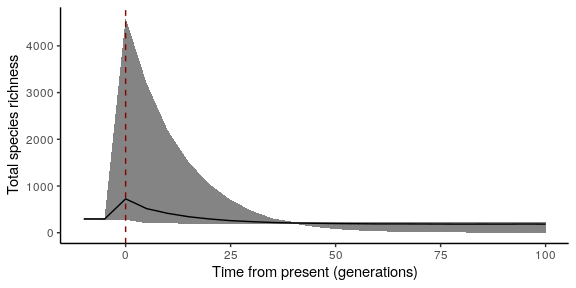

Simulated species richness in the landscape as a function of time.

```r
species_richness_plot <- mean_species_richness %>% ggplot() +
  geom_ribbon(aes(x = 100 - time, ymin = min_species_richness, ymax = max_species_richness), alpha = 0.6) +
  geom_line(aes(
    x = 100 - time,
    y = mean_species_richness
  )) +
  theme_classic() +
  scale_x_continuous("Time from present (generations)") +
  scale_y_continuous("Total species richness", limits = c(0, NA)) +
  geom_vline(aes(xintercept = 0), colour = "darkred", linetype = "dashed")
species_richness_plot
```

## Species abundance distributions over time

We can also extract the abundance of each species at each point in time and use this to plot a species abundance distribution.

```r
mean_species_abundances <- species_abundances %>%
  full_join(sim$getCommunityReferences() %>%
    rename(community_reference = reference),
  by = "community_reference"
  ) %>%
  filter(no_individuals > 0) %>%
  mutate(log_abundance = floor(log2(no_individuals))) %>%
  group_by(log_abundance, community_reference, time, seed) %>%
  summarise(total_species = n()) %>%
  ungroup() %>%
  group_by(time, log_abundance) %>%
  summarise(
    mean_species = mean(total_species),
    max_species = max(total_species),
    min_species = min(total_species)
  )
```

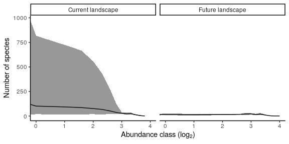

Species abundance distributions (Preston plots) for the current and future landscapes.

```r
sad_plot <- mean_species_abundances %>%
  filter(time == 0 | time == 100) %>%
  mutate(scenario = ifelse(time == 0, "Future landscape", "Current landscape")) %>%
  ggplot() +
  geom_ribbon(aes(x = log_abundance, ymin = min_species, ymax = max_species), alpha = 0.5) +
  geom_line(aes(x = log_abundance, y = mean_species)) +
  facet_grid(. ~ scenario) +
  scale_x_continuous(expression(paste("Abundance class (", log[2], ")")),
    trans = scales::log2_trans(),
    breaks = scales::trans_breaks("log2", function(x) 2^x, n = 6),
    labels = scales::trans_format("log2", scales::math_format(.x))
  ) +
  scale_y_continuous("Number of species") +
  theme_classic()
sad_plot
```

## Spatial distribution of species richness

```r
# Community reference 1 corresponds to the t = 0
mean_species_density <- species_locations %>%
  filter(community_reference %in% c(1, 21)) %>%
  group_by(x, y, seed, community_reference) %>%
  summarise(total_species = length(unique(species_id))) %>%
  group_by(x, y, community_reference) %>%
  summarise(
    mean_species_density = mean(total_species),
    min_species_density = min(total_species),
    max_species_density = max(total_species)
  ) %>%
  inner_join(sim$getCommunityReferences() %>%
    rename(community_reference = reference),
  by = "community_reference"
  ) %>%
  mutate(scenario = ifelse(time == 0,
    "Future landscape",
    "Current landscape"
  ))
```

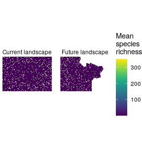

```r
species_density_plot <- mean_species_density %>%
  ggplot() +
  geom_raster(aes(x = x, y = y, fill = mean_species_density)) +
  scale_fill_viridis("Mean\nspecies\nrichness") +
  theme_void() +
  theme(aspect.ratio = total_aspect_ratio) +
  scale_y_reverse() +
  facet_grid(. ~ scenario)
species_density_plot
```

# Biodiversity impact within the national park

The final question we want to answer is the biodiversity impact within the national park itself. To determine the biodiversity within a subset of the landscape there are two approaches we can use; either we supply a `sample_file` to the `applySpeciationRates()` function, which restricts sampling to certain areas of the landscape, or we simply subset from the species locations within R. As we have already extracted the species locations, we shall use the latter approach.

```r
# Find the locations within the national park
national_park_locations <- melt(national_park_data) %>%
  rename(x = Var2, y = Var1) %>%
  filter(value > 0.0) %>%
  distinct(x, y)
# Fetch the individuals within national park
# for the current and future landscape
national_park_individuals <- species_locations %>%
  filter(community_reference %in% c(1, 21)) %>%
  inner_join(national_park_locations, by = c("x", "y"))
national_park_species_density <- national_park_individuals %>%
  group_by(seed, x, y, community_reference) %>%
  summarise(species_richness = length(unique(species_id))) %>%
  group_by(x, y, community_reference) %>%
  summarise(
    mean_species_richness = mean(species_richness),
    min_species_richness = min(species_richness),
    max_species_richness = max(species_richness)
  ) %>%
  full_join(sim$getCommunityReferences() %>%
    rename(community_reference = reference),
  by = "community_reference"
  ) %>%
  mutate(scenario = ifelse(time == 0,
    "Future landscape",
    "Current landscape"
  ))
```

| scenario | min species richness | mean species richness | max species richness |
| --- | --- | --- | --- |
| Future landscape | 96 | 105.7778 | 117 |
| Current landscape | 94 | 109.7778 | 124 |

We can see that the total number of species decreases only slightly in the model, despite the loss of habitat outside the park. Looking at the spatial distribution, the same picture emerges, except for one area along the southeast edge of the park that appears to have a significant decrease in species richness. If this were a pattern that we were interested in, we could repeat the simulation with many different random number seeds (using the `seed` parameter) to determine if this effect is present across simulation runs.

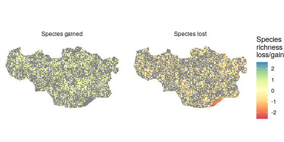

Species richness change within the national park for the current and future landscapes.

```r
species_loss_gain <- national_park_species_density %>%
  select(x, y, scenario, mean_species_richness) %>%
  distinct() %>%
  pivot_wider(
    id_cols = c(x, y),
    names_from = scenario,
    values_from = mean_species_richness
  ) %>%
  mutate(
    `Future landscape` = replace_na(`Future landscape`, 0),
    difference = `Future landscape` - `Current landscape`,
    loss_gain = ifelse(replace_na(difference < 0, FALSE),
      "Species lost\n",
      ifelse(replace_na(difference > 0, FALSE),
        "Species gained\n",
        "No change\n"
      )
    )
  ) %>%
  filter(loss_gain != "No change\n")
plot_max_value <- 0.4*max(abs(national_park_species_density$mean_species_richness), na.rm = TRUE)
national_park_loss_gain_plot <- species_loss_gain %>%
  filter(!is.na(difference)) %>%
  mutate(difference = max(min(plot_max_value, difference), -plot_max_value))%>%
  ggplot() +
  geom_raster(data=national_park_locations, aes(x=x, y=y), fill="grey20", alpha=0.6)+
  geom_raster(aes(x = x, y = y, fill = difference)) +
  scale_fill_distiller("Species\nrichness\nloss/gain",
    palette = "Spectral",
    direction = 1,
    limits = c(-1, 1) * plot_max_value
  ) +
  theme_void() +
  scale_y_reverse() +
  theme(aspect.ratio = 103/189) +
  facet_grid(. ~ loss_gain)
national_park_loss_gain_plot
```

# Conclusions

## Modifications to the scenario

Using the same process outlined above, any other landscape scenarios can be modelled. For example, what if the a much larger area outside is lost, but a habitat corridor is kept? If the reverse is true (i.e. habitat is reclaimed), how quickly does biodiversity recover? By changing the map files and the times they apply to, these scenarios can be modelled in the same way.

# Bibliography

Greenpeace, University of Maryland, and World Resources Institute and Transparent World. 2016. “Intact Forest Landscapes website.” http://intactforests.org/index1.html.